# No Brasil até o passado é duvidoso

#### Wilson Freitas

23/12/2014

Categoria: [finance](http://wilsonfreitas.github.io/category/finance.html)

Tags: [python](http://wilsonfreitas.github.io/tag/python.html) [pandas](http://wilsonfreitas.github.io/tag/pandas.html)

A qualidade dos dados divulgados no mercado financeiro de uma forma geral é ruim. Os dados Brasileiros são muito ruins. As empresas que geram informação em nosso mercado não possuem processos adequados e robustos para a divulgação dos dados, sem falar nas ferramentas utilizadas nos processos. O mercado financeiro, de uma forma geral, é dominado pelo Excel de forma que uma quantidade significativa de informação (quase 100%) passa por planilhas e em diversos casos o formato dos dados é a própria planilha. É um cenário *thrash* onde a falta de estrutura contribui para a proliferação do risco operacional que é responsável por diversas inconsistências encontradas nos dados.

Hoje eu estava fazendo uma análise da série temporal do índice BOVESPA em frequência mensal e de repente identifiquei uma inconsistência nos dados. Os dados foram obtidos no site de séries temporais do [Banco Central do Brasil](https://www3.bcb.gov.br/sgspub) (BCB), ou seja, um lugar sério. Eu utilizei o [Quandl](http://www.quandl.com) para baixar estes dados e já falei a respeito dele em outro [post](http://blog.aboutwilson.net/posts/2014-03/quandl-uma-otima-forma-de-obter-dados-estruturados-em-python/) sobre como obter dados estruturados utilizando Python.

## *Batendo* as informações

O BCB divulga as séries mensais do índice e da variação percentual do índice. No Quandl são as séries `BCB/7845` e `BCB/7832`, respectivamente e é possível baixar as duas séries no mesmo `DataFrame` pandas com o método `Quandl.get`.

```python
import numpy as np
import pandas as pd
import Quandl
import matplotlib.pyplot as plt
import seaborn as sb
%pylab inline
sb.set_context("talk")
```

```python
data = Quandl.get(["BCB/7845", "BCB/7832"])
```

Observando os dados já encontrei a primeira inconsistência. O método `head` retorna o começo da série (assim com `tail` traz o final) e aqui é possível observar que a série do índice é maior do que a série das diferenças percentuais. O que é muito estranho dado que ambas as séries são referentes ao mesmo ativo.

```python
data.head()
```

| Date | BCB.7845 - Value | BCB.7832 - Value |
| --- | --- | --- |
| 1983-07-31 | 62064 | NaN |
| 1983-08-31 | 67535 | NaN |
| 1983-09-30 | 90427 | NaN |
| 1983-10-31 | 1258 | NaN |
| 1983-11-30 | 1678 | NaN |

Dado que ambas as séries são referentes ao mesmo ativo resolvi calcular a variação percentual do índice para bater com a série de variação fornecida pelo BCB.

Olhando o *rabo* da série temos:

```python
data.tail(10)
```

| Date | BCB.7845 - Value | BCB.7832 - Value |
| --- | --- | --- |
| 2014-02-28 | 47094 | -1.14 |
| 2014-03-31 | 50414 | 7.05 |
| 2014-04-30 | 51626 | 2.40 |
| 2014-05-31 | 51239 | -0.75 |
| 2014-06-30 | 53168 | 3.76 |
| 2014-07-31 | 55829 | 5.00 |
| 2014-08-31 | 61288 | 9.78 |
| 2014-09-30 | 54115 | -11.70 |
| 2014-10-31 | 54628 | 0.95 |
| 2014-11-30 | 54724 | 0.18 |

Agora eu calculo a variação percentual da série do índice, o que utilizando o pandas é bem fácil. Para chegar aos mesmo valores fornecidos pelo BCB eu preciso calcular a variação percentual, multiplicar por 100 e arredondar na segunda casa decimal.

```python
vari = data['BCB.7845 - Value'].diff()/data['BCB.7845 - Value']
np.round(100*vari, 2).tail(10)
```

```
Date
2014-02-28    -1.16
2014-03-31     6.59
2014-04-30     2.35
2014-05-31    -0.76
2014-06-30     3.63
2014-07-31     4.77
2014-08-31     8.91
2014-09-30   -13.26
2014-10-31     0.94
2014-11-30     0.18
Name: BCB.7845 - Value, dtype: float64
```

Bem, olhando assim já dá pra ver que as informações não batem. Elas quase batem, mas aqui quase não é suficiente afinal estamos lidando com informação quantitativa e esse cálculo não tem incerteza, ele tem que bater.

Vamos colocar todas as colunas no mesmo `DataFrame`.

```python
data['Perc.change'] = np.round(100*vari, 2)
```

```python
data.tail(10)
```

| Date | BCB.7845 - Value | BCB.7832 - Value | Perc.change |
| --- | --- | --- | --- |
| 2014-02-28 | 47094 | -1.14 | -1.16 |
| 2014-03-31 | 50414 | 7.05 | 6.59 |
| 2014-04-30 | 51626 | 2.40 | 2.35 |
| 2014-05-31 | 51239 | -0.75 | -0.76 |
| 2014-06-30 | 53168 | 3.76 | 3.63 |
| 2014-07-31 | 55829 | 5.00 | 4.77 |
| 2014-08-31 | 61288 | 9.78 | 8.91 |
| 2014-09-30 | 54115 | -11.70 | -13.26 |
| 2014-10-31 | 54628 | 0.95 | 0.94 |
| 2014-11-30 | 54724 | 0.18 | 0.18 |

Só pra avaliar o tamanho do estrago vamos calcular a diferença das variações percentuais e olhar o histograma e aí vamos ter uma idéia do comportamento dessa diferença.

Aqui eu já tenho uma suspeita: diferenças desse tipo aparecem quando há arredondamento nos cálculos e dessa maneira as diferenças deveriam ser da ordem de grandeza da precisão adotada, que neste caso é de 0.01. Não acho que seja isso, pois na tabela acima observamos diferenças muito maiores como em `2014-09-30`. De qualquer forma, vamos ao histograma.

```python
diff_change = data['BCB.7832 - Value'] - data['Perc.change']
diff_change.head(10)
```

```
Date
1983-07-31   NaN
1983-08-31   NaN
1983-09-30   NaN
1983-10-31   NaN
1983-11-30   NaN
1983-12-31   NaN
1984-01-31   NaN
1984-02-29   NaN
1984-03-31   NaN
1984-04-30   NaN
dtype: float64
```

Temos diversos valores nulos devido a diferença de tamanho das séries, vamos remover os valores nulos antes de fazer o histograma.

```python
diff_change = diff_change[~diff_change.isnull()]
```

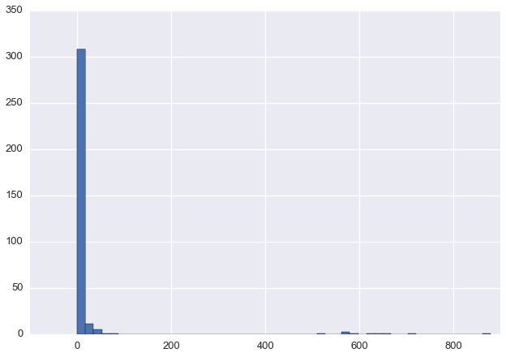

```python
diff_change.hist(bins=50);
```

Os dados apresentam um conjunto de valores extremos que não deveriam estar aí. Só pra olhar o problema mais de perto resolvi fazer alguns agrupamentos pra entender melhor o que acontece. Comecei contando a quantidade de valores negativos e positivos e já vi que a maioria é positiva.

```python
diff_change.groupby(diff_change >= 0).count()
```

```
False      1
True     334
dtype: int64
```

Como os eventos mais comuns são: pagamento de dividendos e juros sobre capital e desmembramento, temos parte do problema explicado. O que ainda me incomoda é saber que em 335 pontos (quase 28 anos) a maioria dos impactos observados é devido a eventos de *down sizing*. Por outro lado estes dados são mensais, o que também dificulta a análise.

Bem, o diagnóstico até agora é de que série do índice não tem o seu valor ajustado, o que introduz variações muito maiores do que as que podem ter ocorrido de fato. Dessa forma os valores do índice divulgados são os valores observados nas datas de fim de mês. Assumindo que a série de diferenças percentuais está correta é possível escolher qualquer data e reconstruir o índice com base nas diferenças. Entretanto, ainda resta verifica se a série de diferenças percentuais é coerente e para verificar isso vou olhar o histograma da série.

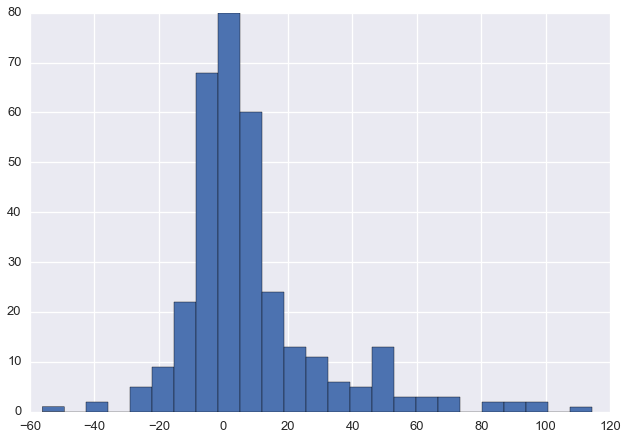

```python
data['BCB.7832 - Value'].hist(bins=25);
```

Observamos algumas variações grandes, no entanto é importante lembrar que a frequência de observação é mensal.

Bem, como fiquei incomodado com alguns retornos grandes resolvi olhar a série crua.

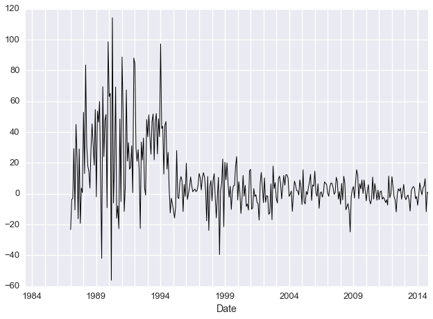

```python
data['BCB.7832 - Value'].plot(linewidth=1, style='k-');
```

Realmente no período nebuloso pré-1994 tivemos variações grandes. Este período é marcado pela hiper-inflação que talvez possa explicar estas oscilações extremas. Para introduzir inflação na análise temos um porém, temos diversos índices de inflação de forma que não sei ao certo qual é o melhor para esta análise e mesmo os índices sofrem alterações na sua metodologia o que também compromente a avaliação histórica. Atualmente o IPCA é utilizado pelo governo para o acompanhamento da meta de inflação e por isso foi escolhido para a análise.

## Deflacionando o IBOVESPA

Vamos começar baixando a série mensal do IPCA no Quandl.

```python
ipca = Quandl.get("BCB/433")
```

```python
ipca.head()
```

| Date | Value |
| --- | --- |
| 1980-01-31 | 6.62 |
| 1980-02-29 | 4.62 |
| 1980-03-31 | 6.04 |
| 1980-04-30 | 5.29 |
| 1980-05-31 | 5.70 |

```python
ipca.tail()
```

| Date | Value |
| --- | --- |
| 2014-07-31 | 0.01 |
| 2014-08-31 | 0.25 |
| 2014-09-30 | 0.57 |
| 2014-10-31 | 0.42 |
| 2014-11-30 | 0.51 |

Felizmente temos uma série longa (desde jan/80). Vamos juntar esta série com os dados de BOVESPA, mas antes vamos remover a série de variações calculadas, pois já considero este problema entendido e não vou mais precisar dela.

```python
data = data.loc[:, ['BCB.7845 - Value', 'BCB.7832 - Value']]
```

```python
data = pd.merge(ipca, data, how='left', left_index=True, right_index=True)
```

A função `merge` do pandas junta os e funciona como um `join` do SQL. Aqui eu passo os `DataFrame` e informo que eu quero utilizar os índices como chaves na junção. O parâmetro `how='left'` me dá algo como um *left-join* onde eu trago todos os índices de `ipca` para o novo `DataFrame`.

```python
data.head()
```

| Date | Value | BCB.7845 - Value | BCB.7832 - Value |
| --- | --- | --- | --- |
| 1980-01-31 | 6.62 | NaN | NaN |
| 1980-02-29 | 4.62 | NaN | NaN |
| 1980-03-31 | 6.04 | NaN | NaN |
| 1980-04-30 | 5.29 | NaN | NaN |
| 1980-05-31 | 5.70 | NaN | NaN |

Como observamos as segunda e terceira colunas são nulas no começo da série por não possuirem informação neste período. Vamos aproveitar para renomear as séries, pois estes nomes dificultam a análise.

```python
data.columns = ['IPCA', 'IBOVESPA', 'IBOVESPA_D']
```

```python
data.tail()
```

| Date | IPCA | IBOVESPA | IBOVESPA_D |
| --- | --- | --- | --- |
| 2014-07-31 | 0.01 | 55829 | 5.00 |
| 2014-08-31 | 0.25 | 61288 | 9.78 |
| 2014-09-30 | 0.57 | 54115 | -11.70 |
| 2014-10-31 | 0.42 | 54628 | 0.95 |
| 2014-11-30 | 0.51 | 54724 | 0.18 |

Como podemos observar o fim da série está completo e o `DataFrame` tem suas colunas com nomes que fazem mais sentido.

Na análise de dados as colunas de tabelas (ou `DataFrame` em nosso caso), assim como as variáveis em um programa, devem fazer sentido. As colunas são as variáveis de fato e são o objeto de interação. Por isso é fundamental que todo *data scientist* trabalhe com os dados de forma higiênica, afinal uma nomenclatura confusa gera uma análise confusa e consequentemente um resultado que fica difícil de explicar. Uma análise higiênica torna-se fácil de explicar e todo o processo de compreenssão é suave e homogêneo, por que de uma forma geral as coisas simplesmente fazem sentido.

$$ 1 + IBOVESPA\_D\_DEFL = \frac{1 + IBOVESPA\_D}{1 + IPCA} $$

onde `IBOVESPA_D_DEFL` é a variação do índice descontada da inflação, ou seja, deflacionada.

```python
ibovespa_d_defl = ((1 + data["IBOVESPA_D"]/100)/(1 + data["IPCA"]/100) - 1)*100
```

Para facilitar a visualização vamos juntar tudo em 1 `DataFrame` antes de gerar os gráficos.

```python
ibovespa_d = pd.DataFrame({'IBOVESPA_DEFL': ibovespa_d_defl, 'IBOVESPA_D': data['IBOVESPA_D']}, index=ibovespa_d_defl.index)
```

Como `ibovespa_d_defl` e `IBOVESPA_D` foram gerados por colunas de um mesmo `DataFrame` então eles possuem os mesmos índices, de forma que para juntar ambos eu criei um novo `DataFrame` utilizando as séries como colunas e informando qual índice utilizar.

Abaixo apresento as duas séries, `IBOVESPA_D` e `IBOVESPA_DEFL`. Podemos observar que os retornos positivos foram reduzidos no período de maior inflação, assim como o pior retorno negativo foi amplificado.

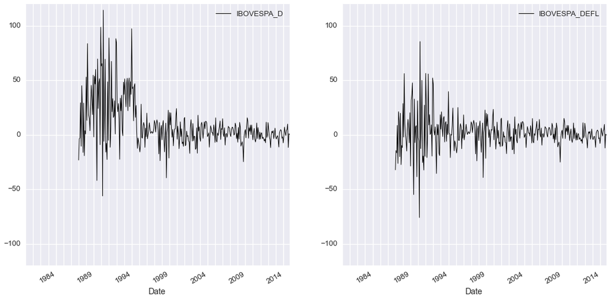

```python
ibovespa_d.plot(subplots=True, ylim=(-120, 120), figsize=(18, 9), layout=(1, 2), linewidth=1);
```

Olhando o histograma das duas séries observa-se que as variações deflacionadas estão mais simétricas. De fato, considerando a frequência dos dados este é um resultado esperado, pois observando dados diários temos variações independentes e sendo os dados mensais somatórios de dados diários este é um resultado esperado (para os mais atentos vale a pena dar uma olhada no [Teorema do Limite Central](http://en.wikipedia.org/wiki/Central_limit_theorem)).

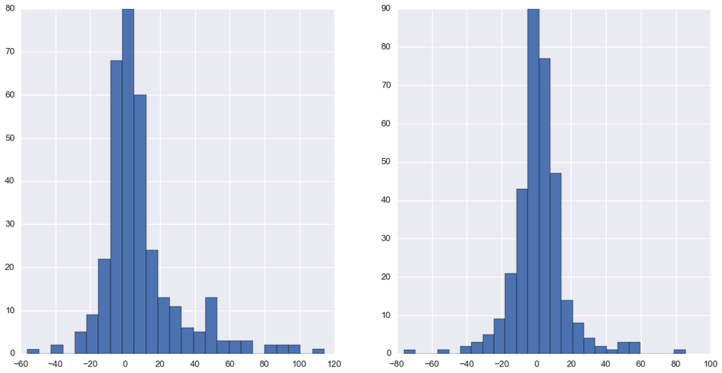

```python
subplots(1, 2, figsize=(18,9))
subplot(121)
ibovespa_d["IBOVESPA_D"].hist(bins=25);
subplot(122)
ibovespa_d["IBOVESPA_DEFL"].hist(bins=25);
```

Apenas para confirmar a observação acima, eu calculo a assimetria das séries (*skewness*) e realmente observo que houve uma redução nesta medida indicando uma distribuição menos assimétrica (ou mais simétrica).

```python
ibovespa_d.skew()
```

```
IBOVESPA_D       1.689262
IBOVESPA_DEFL    0.518155
dtype: float64
```